# Veteran trees and birds

Vojtěch Barták

31 5 2021

# Libraries and data

Let’s load the required libraries.

```r
library(dplyr)
library(ggplot2)
library(lme4)
library(car)
library(performance)
library(rsq)
library(multcomp)
```

Read the data, rename and rescale the variables. (Numerical preditor are rescaled for better convergence of GLMM models.)

```r
df <- read.table("data_birds_trees.txt", sep="\t", header=T) %>%
  filter(Forest_type=="Production_forest") %>%
  mutate(
    ID = ID_study_plot,
    rich = Total_num_of_species,
    rich_sp = Specialist_species,
    rich_gen = Generalist_species,
    sh = as.numeric(scale(H_Trees)),
    ageSD = as.numeric(scale(Age_SD)),
    age = as.numeric(scale(AgeWMean)),
    young = as.numeric(scale(Young_cover)),
    conif = as.numeric(scale(Conifer_cover)),
    broadl = as.numeric(scale(Broadl_cover)),
    n70 = as.numeric(scale(NumLT70DBH)),
    bl70 = as.numeric(scale(NumBroadlLT70DBH)),
    cat70 = as.factor(NumBroadlLT70DBH_ha)
  )
```

# Bird species richness and veteran trees in production forests

## Multicollinearity check

Multicollinearity check using variance inflection factor

```r
vif(glmer(rich ~ conif+broadl+young+n70+bl70+age+ageSD+sh+(1|ID), family=poisson, data=df))
```

```
## boundary (singular) fit: see ?isSingular
```

```
##    conif   broadl    young      n70     bl70      age    ageSD       sh
## 8.150010 6.317853 2.192726 1.960132 1.964826 1.141039 1.293635 1.490950
```

The large value for `conif` and `broadl` suggest these two are correlated. Indeed:

```r
cor(df$conif, df$broadl, method = "spearman")
```

```
## [1] -0.8527536
```

The more coniferous trees, the less broadleaved trees. `conif` has larger VIF, so it should be excluded from the model (it’s effect is - to a large extent - included in the `broadl` predictor.)

Note: multicollinearity does not depend on the response, so it is enough to check for it once. All models will be without `conif`.

## All bird species

Fitting the full model:

```r
m.full <- glmer(rich ~ broadl+young+n70+bl70+age+ageSD+sh+(1|ID),
                data = df, family = poisson)
```

```
## boundary (singular) fit: see ?isSingular
```

As the warning says, there is a singular fit. Although this is commonly attributed to overly complex random effect structure (see Ben Bolker’s comments on the issue available at https://bbolker.github.io/mixedmodels-misc/glmmFAQ.html), this is obviously not our case (we have single random intercept). Another possible reason could be a low actual variation in bird species richness among the study sites. However, this variation was comparable both with variation of specialist species richness and generalist species richness, although we haven’t encountered a singular model fit for neither of these response variables (see below). Moreover, the model outputs are in general accordance with outputs of the models for specialists and generalists, as well as with outputs of corresponding GLM models of total species richness (not reported). Therefore, we decided to report results of these GLMM models, ignoring their singular fits.

### Model selection

Backward selection based on p-values. In each step, the predictor with largest insignificant p-value is excluded:

```r
Anova(m.full)
Anova(update(m.full, ~.-young))
Anova(update(m.full, ~.-young-n70))
Anova(update(m.full, ~.-young-n70-age))
Anova(update(m.full, ~.-young-n70-age-broadl))
Anova(update(m.full, ~.-young-n70-age-broadl-ageSD))
```

[output not shown]

Final model:

```r
m <- glmer(rich ~ bl70+sh+(1|ID), data = df, family = poisson)
```

```
## boundary (singular) fit: see ?isSingular
```

### Final model summary, diagnostics and performance

Model summary:

```r
summary(m)
```

```
## Generalized linear mixed model fit by maximum likelihood (Laplace
##   Approximation) [glmerMod]
##  Family: poisson  ( log )
## Formula: rich ~ bl70 + sh + (1 | ID)
##    Data: df
##
##      AIC      BIC   logLik deviance df.resid
##    840.5    853.3   -416.2    832.5      176
##
## Scaled residuals:
##      Min       1Q   Median       3Q      Max
## -1.51835 -0.47709 -0.00697  0.46670  1.73617
##
## Random effects:
##  Groups Name        Variance Std.Dev.
##  ID     (Intercept) 0        0
## Number of obs: 180, groups:  ID, 20
##
## Fixed effects:
##             Estimate Std. Error z value Pr(>|z|)
## (Intercept)  2.33935    0.02319 100.884  < 2e-16 ***
## bl70         0.07926    0.02130   3.721 0.000199 ***
## sh           0.04137    0.02308   1.793 0.073052 .
## ---
## Signif. codes:  0 '***' 0.001 '**' 0.01 '*' 0.05 '.' 0.1 ' ' 1
##
## Correlation of Fixed Effects:
##      (Intr) bl70
## bl70 -0.078
## sh   -0.041 -0.127
## optimizer (Nelder_Mead) convergence code: 0 (OK)
## boundary (singular) fit: see ?isSingular
```

Significance of predictors:

```r
Anova(m)
```

```
## Analysis of Deviance Table (Type II Wald chisquare tests)
##
## Response: rich
##        Chisq Df Pr(>Chisq)
## bl70 13.8432  1  0.0001987 ***
## sh    3.2131  1  0.0730515 .
## ---
## Signif. codes:  0 '***' 0.001 '**' 0.01 '*' 0.05 '.' 0.1 ' ' 1
```

Veteran broad-leaved trees are highly significant, forest diversity is weakly significant.

Check for possible overdispersion:

```r
check_overdispersion(m)
```

```
## # Overdispersion test
##
##        dispersion ratio =  0.457
##   Pearson's Chi-Squared = 80.408
##                 p-value =      1
```

```
## No overdispersion detected.
```

Model performance:

```r
rsq(m)
```

```
## $model
## [1] 0.1885625
##
## $fixed
## [1] 0.1885625
##
## $random
## [1] 0
```

### Effect plots

Veteran broadleaved trees:

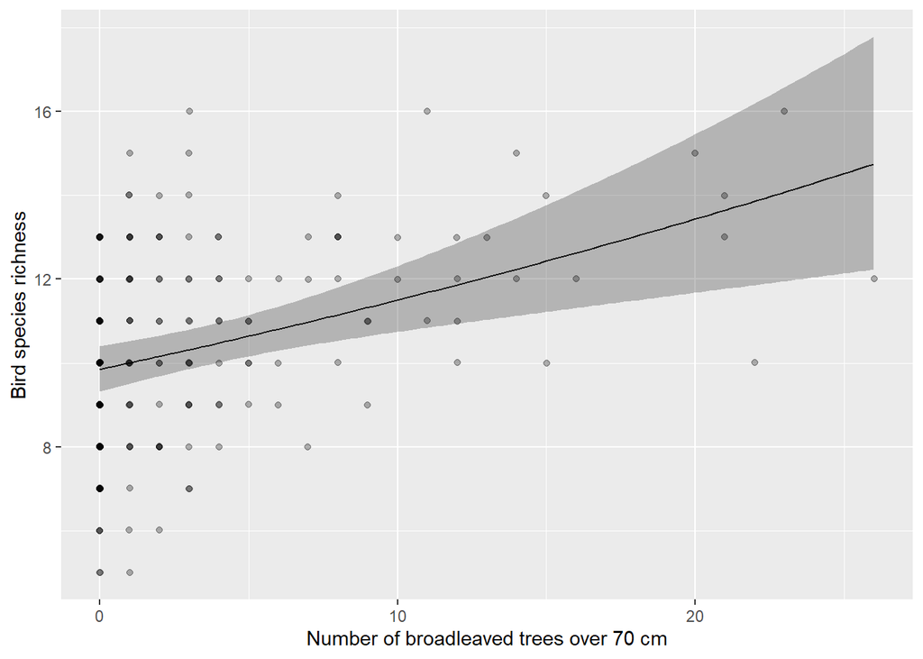

```r
nd <- data.frame(
  bl70 = seq(min(df$bl70), max(df$bl70), length.out = 100),
  sh = mean(df$sh)
)
mm <- model.matrix(~bl70+sh, nd)
y <- mm %*% fixef(m)
pvar <- diag(mm %*% tcrossprod(vcov(m), mm))
nd$rich <- exp(y)
nd$upr <- exp(y+1.96*sqrt(pvar))
nd$lwr <- exp(y-1.96*sqrt(pvar))
ggplot(nd, aes(y=rich, x=bl70*sd(df$NumBroadlLT70DBH)+mean(df$NumBroadlLT70DBH))) +
  geom_line() +
  geom_ribbon(aes(ymin=lwr, ymax=upr), alpha=.3) +
  geom_jitter(data=df, height = 0.01, width = 0.01, alpha=.3) +
  labs(x="Number of broadleaved trees over 70 cm",
       y="Bird species richness")
```

Shannon tree diversity:

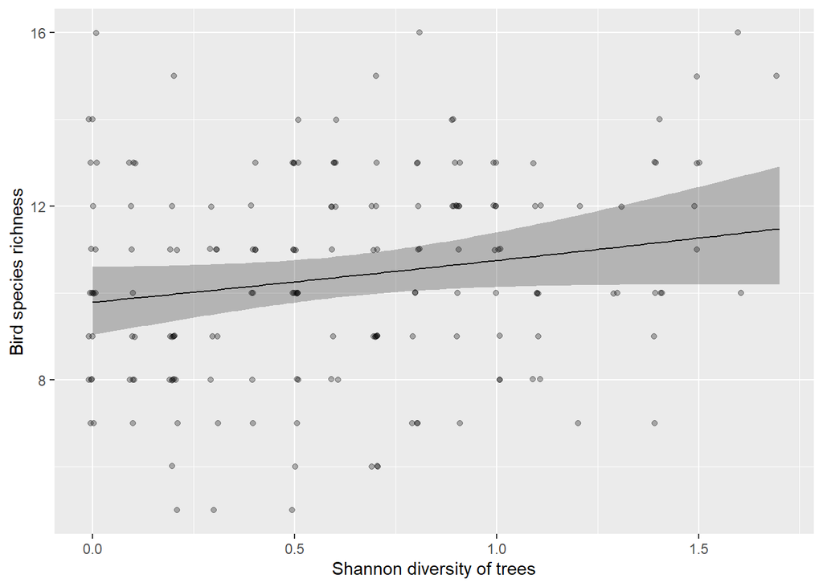

```r
nd2 <- data.frame(
  sh = seq(min(df$sh), max(df$sh), length.out = 100),
  bl70 = mean(df$bl70)
)
mm2 <- model.matrix(~bl70+sh, nd2)
y2 <- mm2 %*% fixef(m)
pvar2 <- diag(mm2 %*% tcrossprod(vcov(m), mm2))
nd2$rich <- exp(y2)
nd2$upr <- exp(y2+1.96*sqrt(pvar2))
nd2$lwr <- exp(y2-1.96*sqrt(pvar2))
ggplot(nd2, aes(y=rich, x=sh*sd(df$H_Trees)+mean(df$H_Trees))) +
  geom_line() +
  geom_ribbon(aes(ymin=lwr, ymax=upr), alpha=.3) +
  geom_jitter(data=df, height = 0.01, width = 0.01, alpha=.3) +
  labs(x="Shannon diversity of trees",
       y="Bird species richness")
```

## Specialist bird species

Full model:

```r
m.full.sp <- glmer(rich_sp ~ broadl+young+n70+bl70+age+ageSD+sh+(1|ID),
                   data = df, family = poisson)
```

### Model selection

```r
Anova(m.full.sp)
```

```
## Analysis of Deviance Table (Type II Wald chisquare tests)
##
## Response: rich_sp
##         Chisq Df Pr(>Chisq)
## broadl 0.0200  1    0.88754
## young  0.1153  1    0.73422
## n70    0.0154  1    0.90124
## bl70   3.2194  1    0.07277 .
## age    1.1069  1    0.29275
## ageSD  0.0849  1    0.77078
## sh     6.2543  1    0.01239 *
## ---
## Signif. codes:  0 '***' 0.001 '**' 0.01 '*' 0.05 '.' 0.1 ' ' 1
```

```r
Anova(update(m.full.sp, ~.-n70))
```

```
## Analysis of Deviance Table (Type II Wald chisquare tests)
##
## Response: rich_sp
##         Chisq Df Pr(>Chisq)
## broadl 0.0170  1    0.89625
## young  0.1280  1    0.72053
## bl70   4.0998  1    0.04289 *
## age    1.1208  1    0.28975
## ageSD  0.0728  1    0.78727
## sh     6.2392  1    0.01250 *
## ---
## Signif. codes:  0 '***' 0.001 '**' 0.01 '*' 0.05 '.' 0.1 ' ' 1
```

```r
Anova(update(m.full.sp, ~.-n70-broadl))
```

```
## Analysis of Deviance Table (Type II Wald chisquare tests)
##
## Response: rich_sp
##        Chisq Df Pr(>Chisq)
## young 0.1203  1    0.72871
## bl70  5.8654  1    0.01544 *
## age   1.1759  1    0.27819
## ageSD 0.0841  1    0.77175
## sh    7.4425  1    0.00637 **
## ---
## Signif. codes:  0 '***' 0.001 '**' 0.01 '*' 0.05 '.' 0.1 ' ' 1
```

```r
Anova(update(m.full.sp, ~.-n70-broadl-ageSD))
```

```
## Analysis of Deviance Table (Type II Wald chisquare tests)
##
## Response: rich_sp
##        Chisq Df Pr(>Chisq)
## young 0.0732  1   0.786736
## bl70  6.4592  1   0.011038 *
## age   1.2268  1   0.268036
## sh    7.3915  1   0.006553 **
## ---
## Signif. codes:  0 '***' 0.001 '**' 0.01 '*' 0.05 '.' 0.1 ' ' 1
```

```r
Anova(update(m.full.sp, ~.-n70-broadl-ageSD-young))
```

```
## Analysis of Deviance Table (Type II Wald chisquare tests)
##
## Response: rich_sp
##       Chisq Df Pr(>Chisq)
## bl70 6.5148  1   0.010698 *
## age  1.2465  1   0.264227
## sh   7.9997  1   0.004679 **
## ---
## Signif. codes:  0 '***' 0.001 '**' 0.01 '*' 0.05 '.' 0.1 ' ' 1
```

```r
Anova(update(m.full.sp, ~.-n70-broadl-ageSD-young-age))
```

```
## Analysis of Deviance Table (Type II Wald chisquare tests)
##
## Response: rich_sp
##       Chisq Df Pr(>Chisq)
## bl70 7.1660  1   0.007430 **
## sh   8.8531  1   0.002926 **
## ---
## Signif. codes:  0 '***' 0.001 '**' 0.01 '*' 0.05 '.' 0.1 ' ' 1
```

Final model:

```r
m.sp <- glmer(rich_sp ~ bl70+sh+(1|ID), data = df, family = poisson)
```

Significance of predictors:

```r
Anova(m.sp)
```

```
## Analysis of Deviance Table (Type II Wald chisquare tests)
##
## Response: rich_sp
##       Chisq Df Pr(>Chisq)
## bl70 7.1660  1   0.007430 **
## sh   8.8531  1   0.002926 **
## ---
## Signif. codes:  0 '***' 0.001 '**' 0.01 '*' 0.05 '.' 0.1 ' ' 1
```

### Final model summary, diagnostics and performance

Model summary:

```r
summary(m.sp)
```

```
## Generalized linear mixed model fit by maximum likelihood (Laplace
##   Approximation) [glmerMod]
##  Family: poisson  ( log )
## Formula: rich_sp ~ bl70 + sh + (1 | ID)
##    Data: df
##
##      AIC      BIC   logLik deviance df.resid
##    752.7    765.5   -372.3    744.7      176
##
## Scaled residuals:
##     Min      1Q  Median      3Q     Max
## -1.6335 -0.5310 -0.1068  0.4898  3.6137
##
## Random effects:
##  Groups Name        Variance Std.Dev.
##  ID     (Intercept) 0.02687  0.1639
## Number of obs: 180, groups:  ID, 20
##
## Fixed effects:
##             Estimate Std. Error z value Pr(>|z|)
## (Intercept)  1.58161    0.05099  31.020  < 2e-16 ***
## bl70         0.08934    0.03337   2.677  0.00743 **
## sh          -0.13015    0.04374  -2.975  0.00293 **
## ---
## Signif. codes:  0 '***' 0.001 '**' 0.01 '*' 0.05 '.' 0.1 ' ' 1
##
## Correlation of Fixed Effects:
##      (Intr) bl70
## bl70 -0.020
## sh    0.026 -0.189
```

Overdispersion check:

```r
check_overdispersion(m.sp)
```

```
## # Overdispersion test
##
##        dispersion ratio =   0.626
##   Pearson's Chi-Squared = 110.160
##                 p-value =       1
```

```
## No overdispersion detected.
```

Model performance:

```r
rsq(m.sp)
```

```
## $model
## [1] 0.2423575
##
## $fixed
## [1] 0.1538785
##
## $random
## [1] 0.08847901
```

### Effect plots

Veteran broadleaved trees:

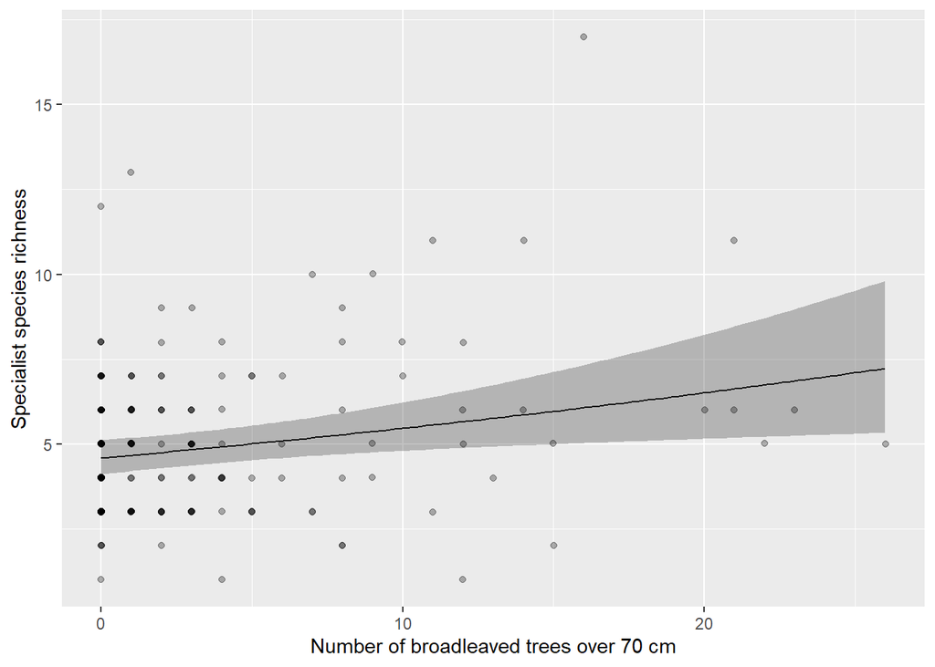

```r
nd.sp <- data.frame(
  bl70 = seq(min(df$bl70), max(df$bl70), length.out = 100),
  sh = mean(df$sh)
)
mm.sp <- model.matrix(~bl70+sh, nd.sp)
y.sp <- mm.sp %*% fixef(m.sp)
pvar.sp <- diag(mm.sp %*% tcrossprod(vcov(m.sp), mm.sp))
nd.sp$rich_sp <- exp(y.sp)
nd.sp$upr <- exp(y.sp+1.96*sqrt(pvar.sp))
nd.sp$lwr <- exp(y.sp-1.96*sqrt(pvar.sp))
ggplot(nd.sp, aes(y=rich_sp, x=bl70*sd(df$NumBroadlLT70DBH)+mean(df$NumBroadlLT70DBH))) +
  geom_line() +
  geom_ribbon(aes(ymin=lwr, ymax=upr), alpha=.3) +
  geom_jitter(data=df, height = 0.01, width = 0.01, alpha=.3) +
  labs(x="Number of broadleaved trees over 70 cm",
       y="Specialist species richness")
```

Shannon tree diversity:

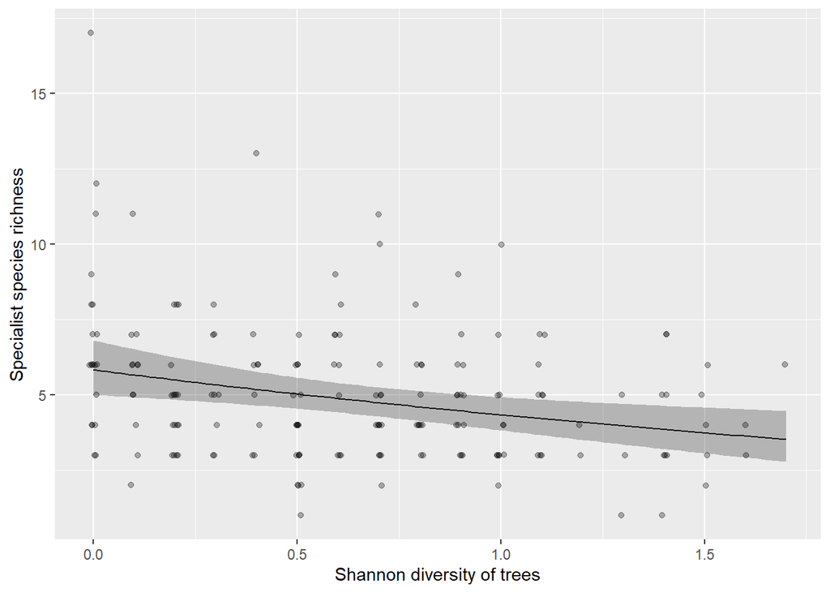

```r
nd.sp2 <- data.frame(
  sh = seq(min(df$sh), max(df$sh), length.out = 100),
  bl70 = mean(df$bl70)
)
mm.sp2 <- model.matrix(~bl70+sh, nd.sp2)
y.sp2 <- mm.sp2 %*% fixef(m.sp)
pvar.sp2 <- diag(mm.sp2 %*% tcrossprod(vcov(m.sp), mm.sp2))
nd.sp2$rich_sp <- exp(y.sp2)
nd.sp2$upr <- exp(y.sp2+1.96*sqrt(pvar.sp2))
nd.sp2$lwr <- exp(y.sp2-1.96*sqrt(pvar.sp2))
ggplot(nd.sp2, aes(y=rich_sp, x=sh*sd(df$H_Trees)+mean(df$H_Trees))) +
  geom_line() +
  geom_ribbon(aes(ymin=lwr, ymax=upr), alpha=.3) +
  geom_jitter(data=df, height = 0.01, width = 0.01, alpha=.3) +
  labs(x="Shannon diversity of trees",
       y="Specialist species richness")
```

## Generalist bird species

Full model:

```r
m.full.gen <- glmer(rich_gen ~ broadl+young+n70+bl70+age+ageSD+sh+(1|ID),
                         data = df, family = poisson)
```

### Model selection

```r
Anova(m.full.gen)
```

```
## Analysis of Deviance Table (Type II Wald chisquare tests)
##
## Response: rich_gen
##         Chisq Df Pr(>Chisq)
## broadl 1.3821  1    0.23975
## young  0.0008  1    0.97791
## n70    0.4710  1    0.49252
## bl70   1.5676  1    0.21056
## age    0.0027  1    0.95833
## ageSD  0.8220  1    0.36459
## sh     5.5216  1    0.01878 *
## ---
## Signif. codes:  0 '***' 0.001 '**' 0.01 '*' 0.05 '.' 0.1 ' ' 1
```

```r
Anova(update(m.full.gen, ~.-young))
```

```
## Analysis of Deviance Table (Type II Wald chisquare tests)
##
## Response: rich_gen
##         Chisq Df Pr(>Chisq)
## broadl 1.3861  1    0.23906
## n70    0.4729  1    0.49166
## bl70   1.6287  1    0.20189
## age    0.0024  1    0.96087
## ageSD  0.8630  1    0.35291
## sh     5.5699  1    0.01827 *
## ---
## Signif. codes:  0 '***' 0.001 '**' 0.01 '*' 0.05 '.' 0.1 ' ' 1
```

```r
Anova(update(m.full.gen, ~.-young-age))
```

```
## Analysis of Deviance Table (Type II Wald chisquare tests)
##
## Response: rich_gen
##         Chisq Df Pr(>Chisq)
## broadl 1.3859  1    0.23911
## n70    0.4886  1    0.48457
## bl70   1.6597  1    0.19765
## ageSD  0.8617  1    0.35327
## sh     5.7091  1    0.01688 *
## ---
## Signif. codes:  0 '***' 0.001 '**' 0.01 '*' 0.05 '.' 0.1 ' ' 1
```

```r
Anova(update(m.full.gen, ~.-young-age-n70))
```

```
## Analysis of Deviance Table (Type II Wald chisquare tests)
##
## Response: rich_gen
##         Chisq Df Pr(>Chisq)
## broadl 1.6353  1    0.20097
## bl70   3.6714  1    0.05535 .
## ageSD  1.3091  1    0.25255
## sh     5.3972  1    0.02017 *
## ---
## Signif. codes:  0 '***' 0.001 '**' 0.01 '*' 0.05 '.' 0.1 ' ' 1
```

```r
Anova(update(m.full.gen, ~.-young-age-n70-ageSD))
```

```
## Analysis of Deviance Table (Type II Wald chisquare tests)
##
## Response: rich_gen
##         Chisq Df Pr(>Chisq)
## broadl 2.2463  1    0.13394
## bl70   4.2675  1    0.03885 *
## sh     5.7195  1    0.01678 *
## ---
## Signif. codes:  0 '***' 0.001 '**' 0.01 '*' 0.05 '.' 0.1 ' ' 1
```

```r
Anova(update(m.full.gen, ~.-young-age-n70-ageSD-broadl))
```

```
## Analysis of Deviance Table (Type II Wald chisquare tests)
##
## Response: rich_gen
##       Chisq Df Pr(>Chisq)
## bl70 10.472  1  0.0012123 **
## sh   12.114  1  0.0005005 ***
## ---
## Signif. codes:  0 '***' 0.001 '**' 0.01 '*' 0.05 '.' 0.1 ' ' 1
```

Final model:

```r
m.gen <- glmer(rich_gen ~ bl70+sh+(1|ID), data = df, family = poisson)
```

Significance of predictors:

```r
Anova(m.gen)
```

```
## Analysis of Deviance Table (Type II Wald chisquare tests)
##
## Response: rich_gen
##       Chisq Df Pr(>Chisq)
## bl70 10.472  1  0.0012123 **
## sh   12.114  1  0.0005005 ***
## ---
## Signif. codes:  0 '***' 0.001 '**' 0.01 '*' 0.05 '.' 0.1 ' ' 1
```

### Final model summary, diagnostics and performance

```r
summary(m.gen)
```

```
## Generalized linear mixed model fit by maximum likelihood (Laplace
##   Approximation) [glmerMod]
##  Family: poisson  ( log )
## Formula: rich_gen ~ bl70 + sh + (1 | ID)
##    Data: df
##
##      AIC      BIC   logLik deviance df.resid
##    839.2    852.0   -415.6    831.2      176
##
## Scaled residuals:
##      Min       1Q   Median       3Q      Max
## -1.65192 -0.53241 -0.04774  0.50298  2.70739
##
## Random effects:
##  Groups Name        Variance Std.Dev.
##  ID     (Intercept) 0.006947 0.08335
## Number of obs: 180, groups:  ID, 20
##
## Fixed effects:
##             Estimate Std. Error z value Pr(>|z|)
## (Intercept)  2.12138    0.03222  65.830  < 2e-16 ***
## bl70         0.08031    0.02482   3.236  0.00121 **
## sh           0.10301    0.02960   3.480  0.00050 ***
## ---
## Signif. codes:  0 '***' 0.001 '**' 0.01 '*' 0.05 '.' 0.1 ' ' 1
##
## Correlation of Fixed Effects:
##      (Intr) bl70
## bl70 -0.049
## sh   -0.094 -0.180
```

Overdispersion check:

```r
check_overdispersion(m.gen)
```

```
## # Overdispersion test
##
##        dispersion ratio =   0.611
##   Pearson's Chi-Squared = 107.539
##                 p-value =       1
```

```
## No overdispersion detected.
```

Model performance:

```r
rsq(m.gen)
```

```
## $model
## [1] 0.2228282
##
## $fixed
## [1] 0.1995329
##
## $random
## [1] 0.02329537
```

### Effect plots

Veteran broadleaved trees:

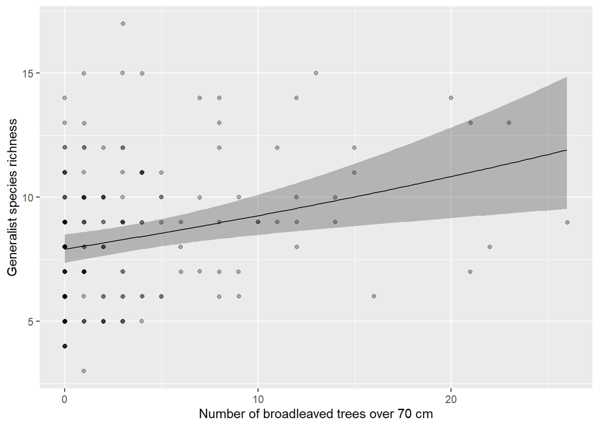

```r
nd.gen <- data.frame(
  bl70 = seq(min(df$bl70), max(df$bl70), length.out = 100),
  sh = mean(df$sh)
)
mm.gen <- model.matrix(~bl70+sh, nd.gen)
y.gen <- mm.gen %*% fixef(m.gen)
pvar.gen <- diag(mm.gen %*% tcrossprod(vcov(m.gen), mm.gen))
nd.gen$rich_gen <- exp(y.gen)
nd.gen$upr <- exp(y.gen+1.96*sqrt(pvar.gen))
nd.gen$lwr <- exp(y.gen-1.96*sqrt(pvar.gen))
ggplot(nd.gen, aes(y=rich_gen, x=bl70*sd(df$NumBroadlLT70DBH)+mean(df$NumBroadlLT70DBH))) +
  geom_line() +
  geom_ribbon(aes(ymin=lwr, ymax=upr), alpha=.3) +
  geom_jitter(data=df, height = 0.01, width = 0.01, alpha=.3) +
  labs(x="Number of broadleaved trees over 70 cm",
       y="Generalist species richness")
```

Shannon tree diversity:

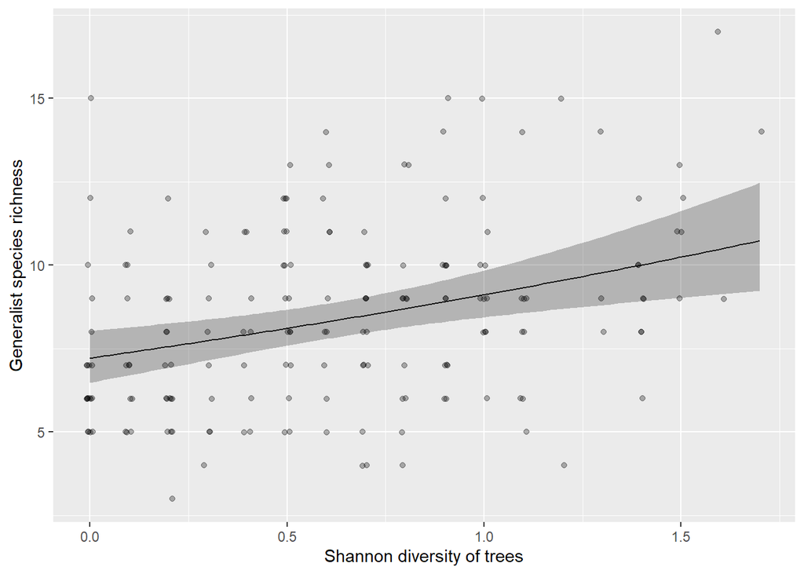

```r
nd.gen2 <- data.frame(
  sh = seq(min(df$sh), max(df$sh), length.out = 100),
  bl70 = mean(df$bl70)
)
mm.gen2 <- model.matrix(~bl70+sh, nd.gen2)
y.gen2 <- mm.gen2 %*% fixef(m.gen)
pvar.gen2 <- diag(mm.gen2 %*% tcrossprod(vcov(m.gen), mm.gen2))
nd.gen2$rich_gen <- exp(y.gen2)
nd.gen2$upr <- exp(y.gen2+1.96*sqrt(pvar.gen2))
nd.gen2$lwr <- exp(y.gen2-1.96*sqrt(pvar.gen2))
ggplot(nd.gen2, aes(y=rich_gen, x=sh*sd(df$H_Trees)+mean(df$H_Trees))) +
  geom_line() +
  geom_ribbon(aes(ymin=lwr, ymax=upr), alpha=.3) +
  geom_jitter(data=df, height = 0.01, width = 0.01, alpha=.3) +
  labs(x="Shannon diversity of trees",
       y="Generalist species richness")
```

# Veteran tree density categories both in production and natural forests

```r
df2 <- read.table("data_birds_trees.txt", sep="\t", header=T) %>%
  mutate(
    ID = ID_study_plot,
    rich = Total_num_of_species,
    rich_sp = Specialist_species,
    rich_gen = Generalist_species,
    cat70 = as.factor(NumBroadlLT70DBH_ha)
  )
```

## All bird species

Model fitting, summary, diagnostics and performance:

```r
m.dens <- glmer(rich~cat70+(1|ID), data=df2, family=poisson)
```

```
## boundary (singular) fit: see ?isSingular
```

```r
check_overdispersion(m.dens)
```

```
## # Overdispersion test
##
##        dispersion ratio =  0.440
##   Pearson's Chi-Squared = 85.374
##                 p-value =      1
```

```
## No overdispersion detected.
```

```r
summary(m.dens)
```

```
## Generalized linear mixed model fit by maximum likelihood (Laplace
##   Approximation) [glmerMod]
##  Family: poisson  ( log )
## Formula: rich ~ cat70 + (1 | ID)
##    Data: df2
##
##      AIC      BIC   logLik deviance df.resid
##    936.8    956.5   -462.4    924.8      194
##
## Scaled residuals:
##     Min      1Q  Median      3Q     Max
## -1.7125 -0.4770  0.0000  0.4961  1.6715
##
## Random effects:
##  Groups Name        Variance Std.Dev.
##  ID     (Intercept) 0        0
## Number of obs: 200, groups:  ID, 20
##
## Fixed effects:
##             Estimate Std. Error z value Pr(>|z|)
## (Intercept)  2.23824    0.03931  56.932  < 2e-16 ***
## cat70B 0<>1  0.11946    0.05588   2.138 0.032535 *
## cat70C1<>3   0.15966    0.06692   2.386 0.017042 *
## cat70D3<>9   0.30336    0.07404   4.097 4.19e-05 ***
## cat70R       0.27136    0.07490   3.623 0.000291 ***
## ---
## Signif. codes:  0 '***' 0.001 '**' 0.01 '*' 0.05 '.' 0.1 ' ' 1
##
## Correlation of Fixed Effects:
##             (Intr) c70B0< c70C1< c70D3<
## cat70B 0<>1 -0.704
## cat70C1<>3  -0.587  0.413
## cat70D3<>9  -0.531  0.374  0.312
## cat70R      -0.525  0.369  0.308  0.279
## optimizer (Nelder_Mead) convergence code: 0 (OK)
## boundary (singular) fit: see ?isSingular
```

```r
Anova(m.dens)
```

```
## Analysis of Deviance Table (Type II Wald chisquare tests)
##
## Response: rich
##        Chisq Df Pr(>Chisq)
## cat70 23.852  4   8.55e-05 ***
## ---
## Signif. codes:  0 '***' 0.001 '**' 0.01 '*' 0.05 '.' 0.1 ' ' 1
```

```r
rsq(m.dens)
```

```
## $model
## [1] 0.223103
##
## $fixed
## [1] 0.223103
##
## $random
## [1] 0
```

Effect plot:

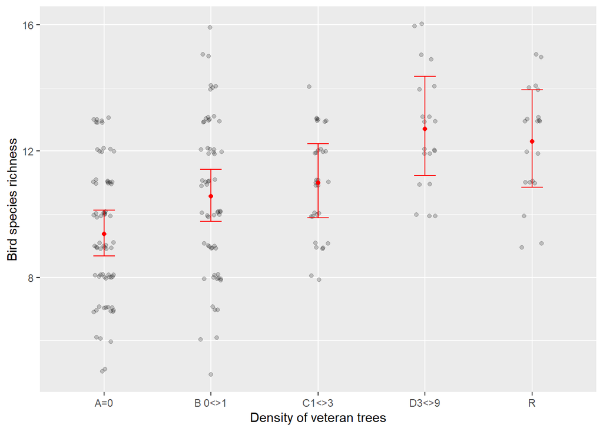

```r
nd.dens <- data.frame(cat70=factor(levels(df2$cat70), levels=levels(df2$cat70)))
mm.dens <- model.matrix(~cat70, nd.dens)
y.dens <- mm.dens %*% fixef(m.dens)
pvar.dens <- diag(mm.dens %*% tcrossprod(vcov(m.dens), mm.dens))
nd.dens$rich <- exp(y.dens)
nd.dens$upr <- exp(y.dens + 1.96*sqrt(pvar.dens))
nd.dens$lwr <- exp(y.dens - 1.96*sqrt(pvar.dens))
ggplot(nd.dens, aes(x=cat70, y=rich)) +
  geom_jitter(data=df2, alpha=.2, width = .1, height = .1) +
  geom_point(color="red") +
  geom_errorbar(aes(ymin=lwr, ymax=upr), width=.2, color="red") +
  labs(x="Density of veteran trees",y="Bird species richness")
```

Multiple comparisons:

```r
summary(glht(m.dens, linfct=mcp(cat70="Tukey")))
```

```
##
##   Simultaneous Tests for General Linear Hypotheses
##
## Multiple Comparisons of Means: Tukey Contrasts
##
##
## Fit: glmer(formula = rich ~ cat70 + (1 | ID), data = df2, family = poisson)
##
## Linear Hypotheses:
##                     Estimate Std. Error z value Pr(>|z|)
## B 0<>1 - A=0 == 0    0.11946    0.05588   2.138   0.1993
## C1<>3 - A=0 == 0     0.15966    0.06692   2.386   0.1159
## D3<>9 - A=0 == 0     0.30336    0.07404   4.097   <0.001 ***
## R - A=0 == 0         0.27136    0.07490   3.623   0.0026 **
## C1<>3 - B 0<>1 == 0  0.04019    0.06716   0.598   0.9746
## D3<>9 - B 0<>1 == 0  0.18390    0.07426   2.476   0.0933 .
## R - B 0<>1 == 0      0.15189    0.07512   2.022   0.2499
## D3<>9 - C1<>3 == 0   0.14371    0.08288   1.734   0.4064
## R - C1<>3 == 0       0.11170    0.08365   1.335   0.6632
## R - D3<>9 == 0      -0.03200    0.08945  -0.358   0.9964
## ---
## Signif. codes:  0 '***' 0.001 '**' 0.01 '*' 0.05 '.' 0.1 ' ' 1
## (Adjusted p values reported -- single-step method)
```

## Specialist species

Model fitting, summary, diagnostics and performance:

```r
m.dens.sp <- glmer(rich_sp~cat70+(1|ID), data=df2, family=poisson)
check_overdispersion(m.dens.sp)
```

```
## # Overdispersion test
##
##        dispersion ratio =   0.641
##   Pearson's Chi-Squared = 124.337
##                 p-value =       1
```

```
## No overdispersion detected.
```

```r
summary(m.dens.sp)
```

```
## Generalized linear mixed model fit by maximum likelihood (Laplace
##   Approximation) [glmerMod]
##  Family: poisson  ( log )
## Formula: rich_sp ~ cat70 + (1 | ID)
##    Data: df2
##
##      AIC      BIC   logLik deviance df.resid
##    847.8    867.6   -417.9    835.8      194
##
## Scaled residuals:
##     Min      1Q  Median      3Q     Max
## -1.7038 -0.5429 -0.1223  0.4612  3.4139
##
## Random effects:
##  Groups Name        Variance Std.Dev.
##  ID     (Intercept) 0.0484   0.22
## Number of obs: 200, groups:  ID, 20
##
## Fixed effects:
##             Estimate Std. Error z value Pr(>|z|)
## (Intercept)  1.51028    0.07586  19.909   <2e-16 ***
## cat70B 0<>1  0.07998    0.08203   0.975   0.3295
## cat70C1<>3   0.04720    0.10153   0.465   0.6420
## cat70D3<>9   0.22109    0.11088   1.994   0.0461 *
## cat70R      -0.05798    0.12163  -0.477   0.6336
## ---
## Signif. codes:  0 '***' 0.001 '**' 0.01 '*' 0.05 '.' 0.1 ' ' 1
##
## Correlation of Fixed Effects:
##             (Intr) c70B0< c70C1< c70D3<
## cat70B 0<>1 -0.521
## cat70C1<>3  -0.419  0.370
## cat70D3<>9  -0.371  0.332  0.333
## cat70R      -0.356  0.323  0.261  0.250
```

```r
Anova(m.dens.sp)
```

```
## Analysis of Deviance Table (Type II Wald chisquare tests)
##
## Response: rich_sp
##        Chisq Df Pr(>Chisq)
## cat70 5.4036  4     0.2483
```

```r
rsq(m.dens.sp)
```

```
## $model
## [1] 0.2181833
##
## $fixed
## [1] 0.05197006
##
## $random
## [1] 0.1662132
```

No significance.

## Generalist species

```r
m.dens.gen <- glmer(rich_gen~cat70+(1|ID), data=df2, family=poisson)
check_overdispersion(m.dens.gen)
```

```
## # Overdispersion test
##
##        dispersion ratio =   0.581
##   Pearson's Chi-Squared = 112.720
##                 p-value =       1
```

```
## No overdispersion detected.
```

```r
summary(m.dens.gen)
```

```
## Generalized linear mixed model fit by maximum likelihood (Laplace
##   Approximation) [glmerMod]
##  Family: poisson  ( log )
## Formula: rich_gen ~ cat70 + (1 | ID)
##    Data: df2
##
##      AIC      BIC   logLik deviance df.resid
##    947.2    967.0   -467.6    935.2      194
##
## Scaled residuals:
##      Min       1Q   Median       3Q      Max
## -1.63233 -0.58935 -0.06201  0.48552  2.13583
##
## Random effects:
##  Groups Name        Variance Std.Dev.
##  ID     (Intercept) 0.01536  0.1239
## Number of obs: 200, groups:  ID, 20
##
## Fixed effects:
##             Estimate Std. Error z value Pr(>|z|)
## (Intercept)  2.01631    0.05256  38.365  < 2e-16 ***
## cat70B 0<>1  0.11904    0.06326   1.882  0.05985 .
## cat70C1<>3   0.19875    0.07615   2.610  0.00905 **
## cat70D3<>9   0.34195    0.08536   4.006 6.17e-05 ***
## cat70R       0.42354    0.07972   5.313 1.08e-07 ***
## ---
## Signif. codes:  0 '***' 0.001 '**' 0.01 '*' 0.05 '.' 0.1 ' ' 1
##
## Correlation of Fixed Effects:
##             (Intr) c70B0< c70C1< c70D3<
## cat70B 0<>1 -0.595
## cat70C1<>3  -0.501  0.404
## cat70D3<>9  -0.447  0.355  0.325
## cat70R      -0.477  0.395  0.328  0.297
```

```r
Anova(m.dens.gen)
```

```
## Analysis of Deviance Table (Type II Wald chisquare tests)
##
## Response: rich_gen
##        Chisq Df Pr(>Chisq)
## cat70 35.917  4  3.009e-07 ***
## ---
## Signif. codes:  0 '***' 0.001 '**' 0.01 '*' 0.05 '.' 0.1 ' ' 1
```

```r
rsq(m.dens.gen)
```

```
## $model
## [1] 0.2519729
##
## $fixed
## [1] 0.19853
##
## $random
## [1] 0.05344282
```

Effect plot:

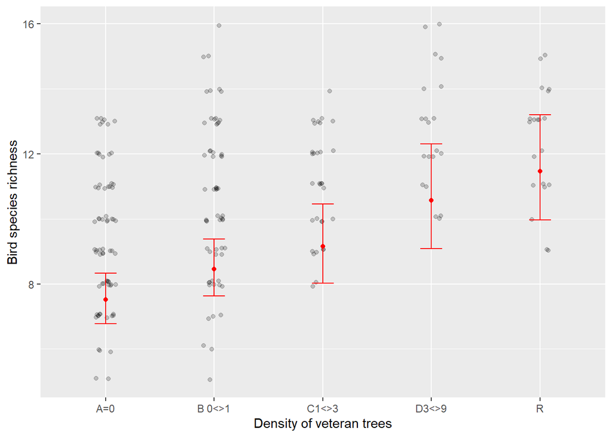

```r
nd.dens.gen <- data.frame(cat70=factor(levels(df2$cat70), levels=levels(df2$cat70)))
mm.dens.gen <- model.matrix(~cat70, nd.dens.gen)
y.dens.gen <- mm.dens.gen %*% fixef(m.dens.gen)
pvar.dens.gen <- diag(mm.dens.gen %*% tcrossprod(vcov(m.dens.gen), mm.dens.gen))
nd.dens.gen$rich <- exp(y.dens.gen)
nd.dens.gen$upr <- exp(y.dens.gen + 1.96*sqrt(pvar.dens.gen))
nd.dens.gen$lwr <- exp(y.dens.gen - 1.96*sqrt(pvar.dens.gen))
ggplot(nd.dens.gen, aes(x=cat70, y=rich)) +
  geom_jitter(data=df2, alpha=.2, width = .1, height = .1) +
  geom_point(color="red") +
  geom_errorbar(aes(ymin=lwr, ymax=upr), width=.2, color="red") +
  labs(x="Density of veteran trees",y="Bird species richness")
```

Multiple comparisons:

```r
summary(glht(m.dens.gen, linfct=mcp(cat70="Tukey")))
```

```
##
##   Simultaneous Tests for General Linear Hypotheses
##
## Multiple Comparisons of Means: Tukey Contrasts
##
##
## Fit: glmer(formula = rich_gen ~ cat70 + (1 | ID), data = df2, family = poisson)
##
## Linear Hypotheses:
##                     Estimate Std. Error z value Pr(>|z|)
## B 0<>1 - A=0 == 0    0.11904    0.06326   1.882  0.32175
## C1<>3 - A=0 == 0     0.19875    0.07615   2.610  0.06678 .
## D3<>9 - A=0 == 0     0.34195    0.08536   4.006  < 0.001 ***
## R - A=0 == 0         0.42354    0.07972   5.313  < 0.001 ***
## C1<>3 - B 0<>1 == 0  0.07970    0.07688   1.037  0.83519
## D3<>9 - B 0<>1 == 0  0.22290    0.08633   2.582  0.07180 .
## R - B 0<>1 == 0      0.30450    0.07985   3.813  0.00127 **
## D3<>9 - C1<>3 == 0   0.14320    0.09413   1.521  0.54282
## R - C1<>3 == 0       0.22480    0.09039   2.487  0.09134 .
## R - D3<>9 == 0       0.08159    0.09795   0.833  0.91867
## ---
## Signif. codes:  0 '***' 0.001 '**' 0.01 '*' 0.05 '.' 0.1 ' ' 1
## (Adjusted p values reported -- single-step method)
```